# Final Project

MSCA 31006 Time Series Analysis and Forecasting

Swathi Ganesan

2023-08-06

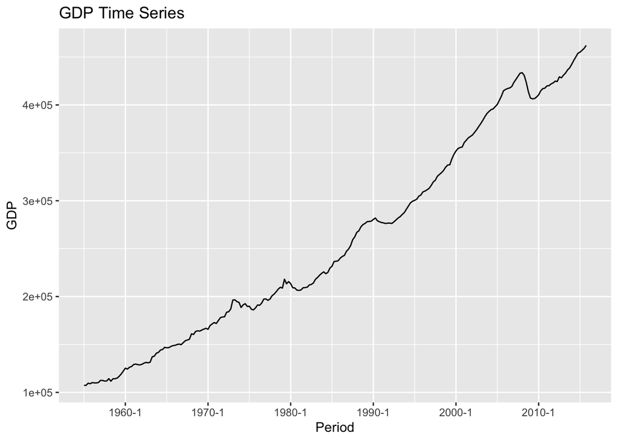

```r
# Read the Excel file
data <- read_excel("TS_Project_Data.xlsx")

# Convert the 'Period' column to year-quarter format
data$Period <- as.yearqtr(data$Period, format = "%Y Q%q")

# Visualize the time series
ggplot(data, aes(x = Period, y = GDP)) +
  geom_line() +
  labs(title = "GDP Time Series", y = "GDP")
```

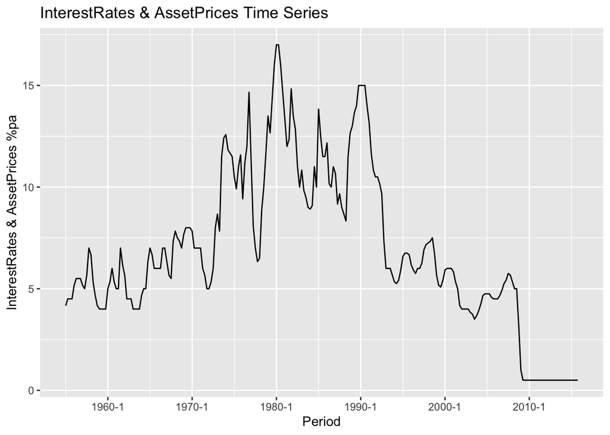

```r
ggplot(data, aes(x = Period, y = InterestRates_AssetPrices)) +
  geom_line() +
  labs(title = "InterestRates & AssetPrices Time Series", y = "InterestRates & AssetPrices %pa")
```

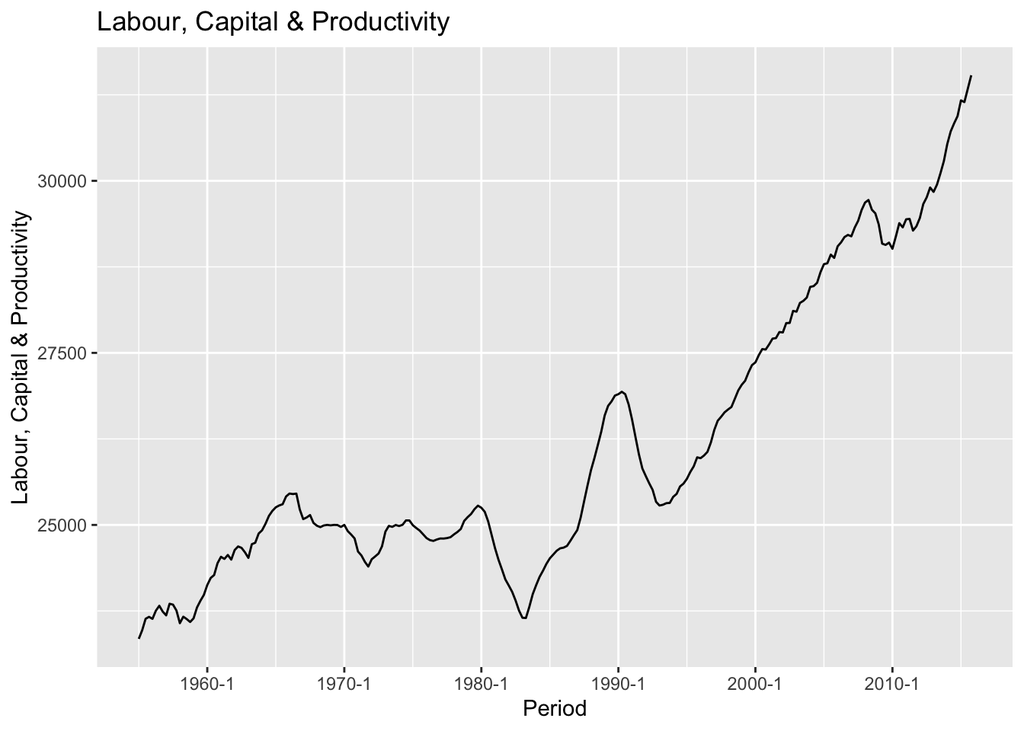

```r
ggplot(data, aes(x = Period, y = Labour_Capital_Prod)) +
  geom_line() +
  labs(title = "Labour, Capital & Productivity", y = "Labour, Capital & Productivity")
```

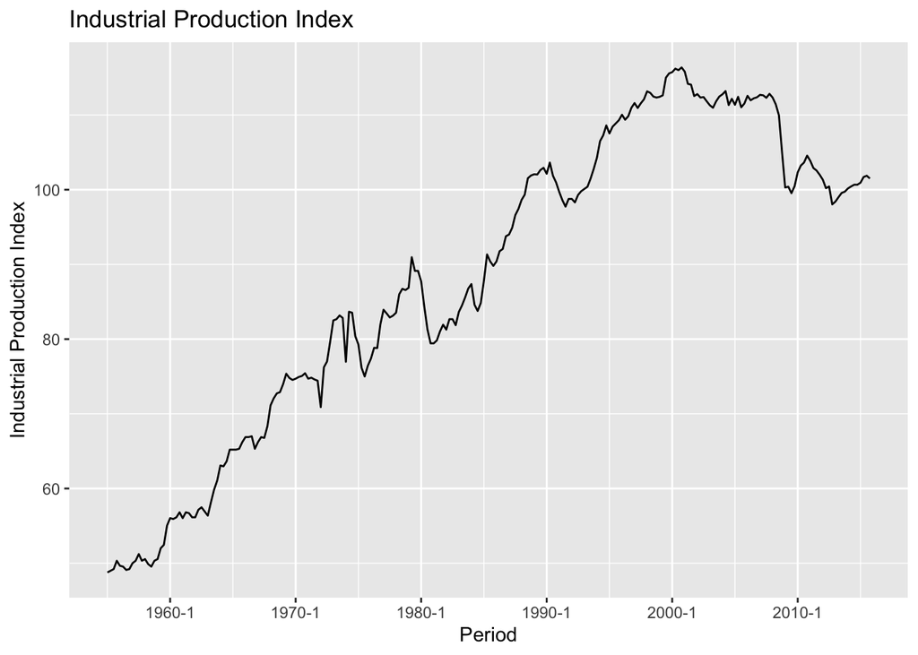

```r
ggplot(data, aes(x = Period, y = IPI)) +
  geom_line() +
  labs(title = "Industrial Production Index", y = "Industrial Production Index")
```

```r
# Convert "Period" to a Date object
data$Period <- as.Date(paste(data$Period, "01", sep = "-"), format = "%Y Q%m-%d")

# Extract year and quarter components
data$Year <- as.numeric(format(data$Period, "%Y"))
data$Quarter <- as.numeric(format(data$Period, "%m"))
```

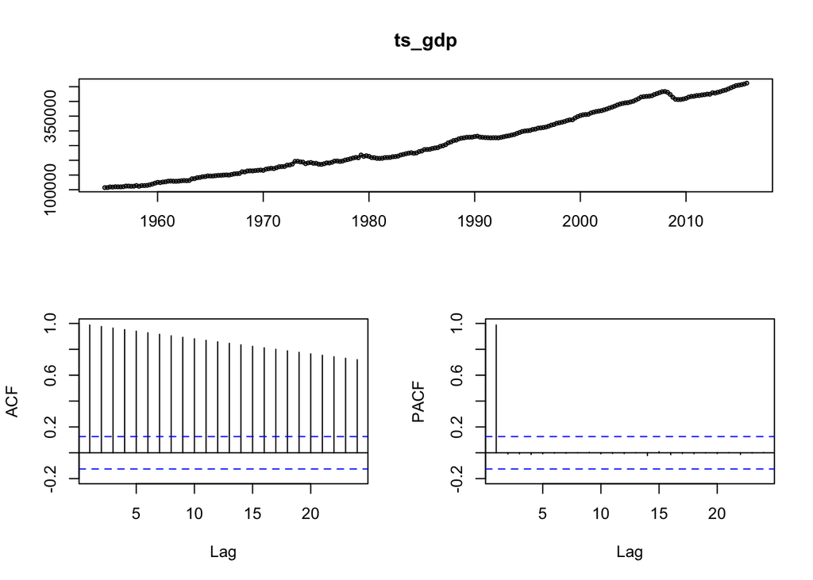

```r
# Create a time series object
ts_gdp <- ts(data$GDP, start = c(data$Year[1], data$Quarter[1]), frequency = 4)

#Plotting the time series
tsdisplay(ts_gdp)
```

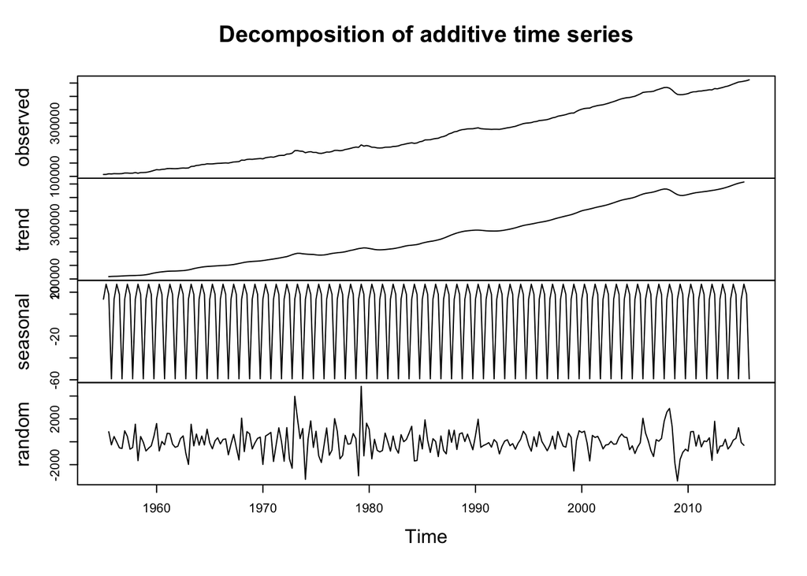

```r
#decompose data
dedat <- decompose(ts_gdp)
plot(dedat)
```

We can observe a trend in the GDP data.

```r
# Test for stationarity

# Perform ADF test
adf_test <- adf.test(ts_gdp)
print(adf_test)
```

```
##
##  Augmented Dickey-Fuller Test
##
## data:  ts_gdp
## Dickey-Fuller = -1.8961, Lag order = 6, p-value = 0.6195
## alternative hypothesis: stationary
```

```r
kpss_test <- kpss.test(ts_gdp)
print(kpss_test)
```

```
##
##  KPSS Test for Level Stationarity
##
## data:  ts_gdp
## KPSS Level = 4.8955, Truncation lag parameter = 4, p-value = 0.01
```

Augmented Dickey-Fuller (ADF) Test: Interpretation: Since the p-value (0.6195) is greater than the significance level (usually 0.05), we fail to reject the null hypothesis. This suggests that the time series is not stationary.

KPSS Test for Level Stationarity: Interpretation: The p-value (0.01) is less than the significance level, which suggests that we can reject the null hypothesis. This indicates that the time series is likely non-stationary.

In summary, both tests suggest that the time series data is non-stationary.

Since the data is non-stationary, you may need to perform differencing to make it stationary before proceeding with time series analysis and forecasting.

```r
# Differencing the time series
ts_gdp_diff <- diff(ts_gdp)

# Check the stationarity of the differenced series using ADF and KPSS tests
adf_test_result_diff <- adf.test(ts_gdp_diff)
kpss_test_result_diff <- kpss.test(ts_gdp_diff)

print(adf_test_result_diff)
```

```
##
##  Augmented Dickey-Fuller Test
##
## data:  ts_gdp_diff
## Dickey-Fuller = -5.1185, Lag order = 6, p-value = 0.01
## alternative hypothesis: stationary
```

```r
print(kpss_test_result_diff)
```

```
##
##  KPSS Test for Level Stationarity
##
## data:  ts_gdp_diff
## KPSS Level = 0.3578, Truncation lag parameter = 4, p-value = 0.09535
```

Augmented Dickey-Fuller (ADF) Test: Interpretation: The p-value (0.01) is less than the significance level, which allows us to reject the null hypothesis. This suggests that the differenced time series is likely stationary.

KPSS Test for Level Stationarity: Interpretation: The p-value (0.09535) is greater than the significance level (usually 0.05), which suggests that we fail to reject the null hypothesis. This indicates that the differenced time series is likely stationary.

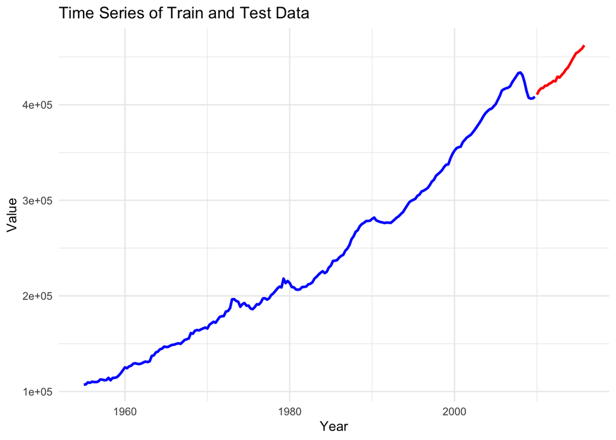

```r
# Perform train-test split
train_data <- window(ts_gdp, end = c(2009, 4))  # Training data until 2009 Q4
test_data <- window(ts_gdp, start = c(2010, 1)) # Test data from 2010 Q1 onwards
number_of_forecasts = 24

# Plot time series of train and test data
ggplot() +
  geom_line(data = as.data.frame(train_data), aes(x = time(train_data), y = train_data), color = "blue", linetype = "solid", size = 1) +
  geom_line(data = as.data.frame(test_data), aes(x = time(test_data), y = test_data), color = "red", linetype = "solid", size = 1) +
  labs(title = "Time Series of Train and Test Data", x = "Year", y = "Value") +
  theme_minimal()
```

Exponential smoothing is a popular method used in time series forecasting to predict future values based on the weighted average of past observations. It is particularly useful for forecasting data with a level and no clear trend or seasonality. Double Exponential Smoothing (Holt’s Linear Exponential Smoothing): This method is used for data with a trend but no seasonality. It includes two smoothing parameters (alpha and beta) to capture the level and trend components.

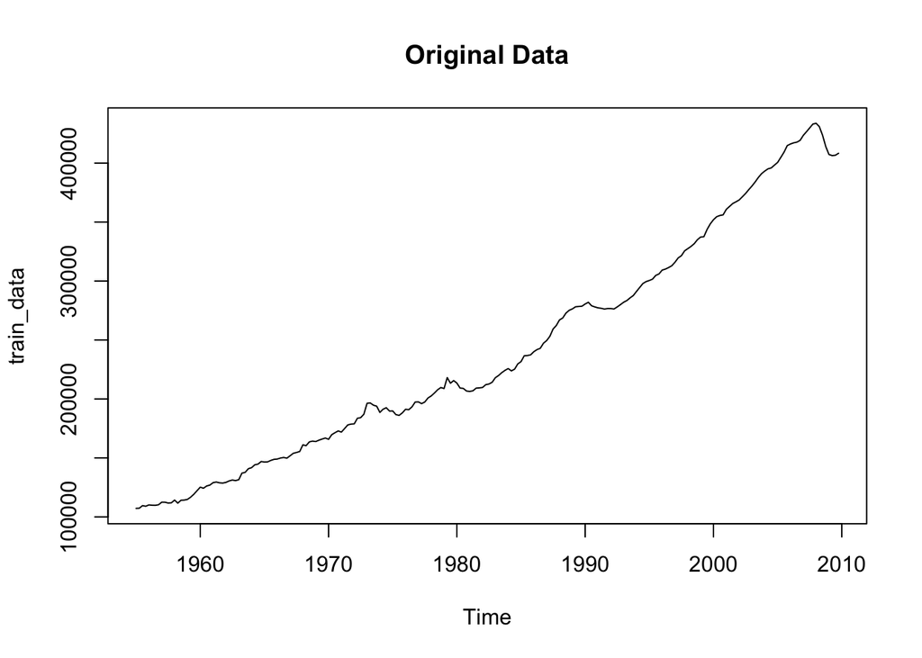

```r
# Perform first-order differencing to make the data stationary
diff_gdp_train <- diff(train_data)

double_exp_fit <- HoltWinters(diff_gdp_train, beta = TRUE)
forecast_values <- forecast(double_exp_fit, h = number_of_forecasts)

# Print the original data, differenced data, and final forecasts
# Plot original data, differenced data, and forecasted values
plot(train_data, main = "Original Data")
```

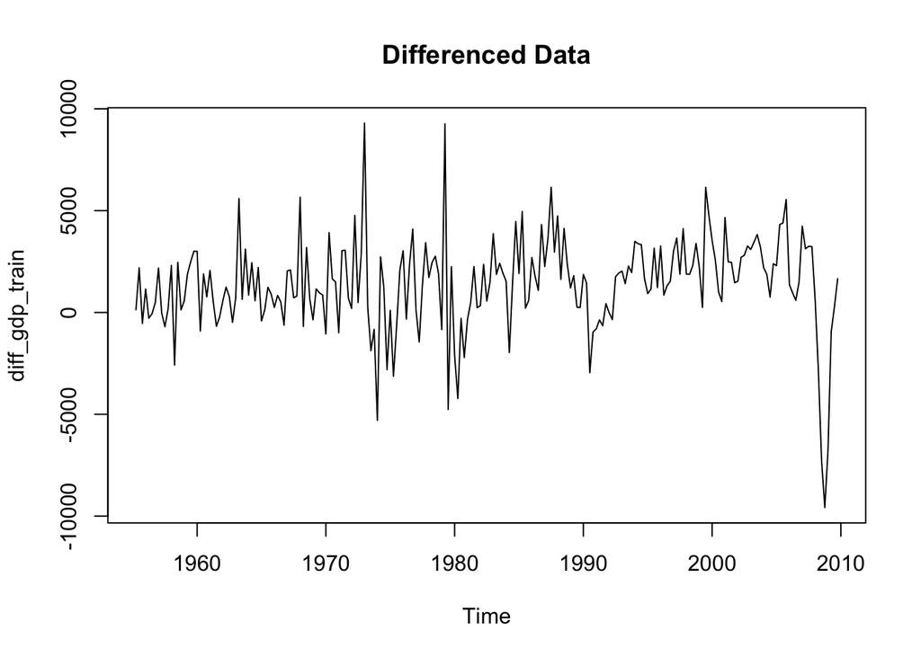

```r
plot(diff_gdp_train, main = "Differenced Data")
```

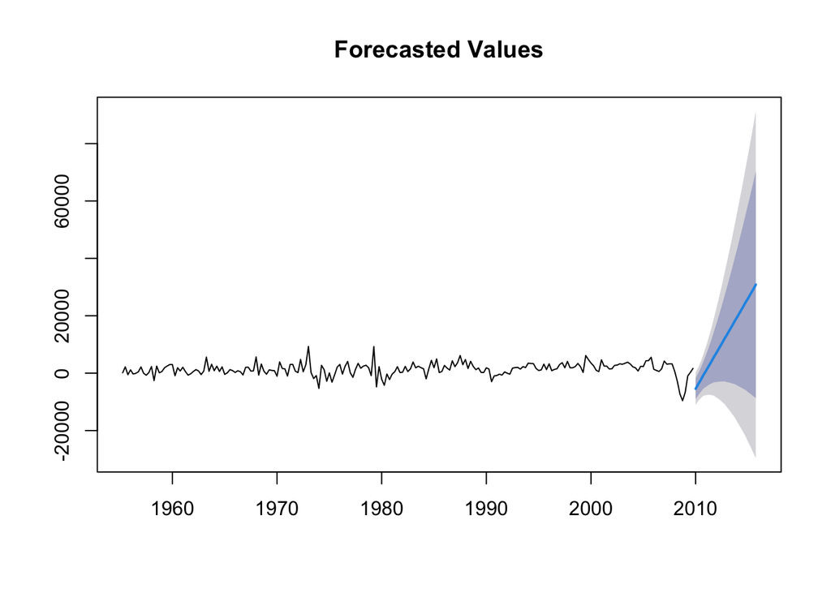

```r
plot(forecast_values, main = "Forecasted Values")
```

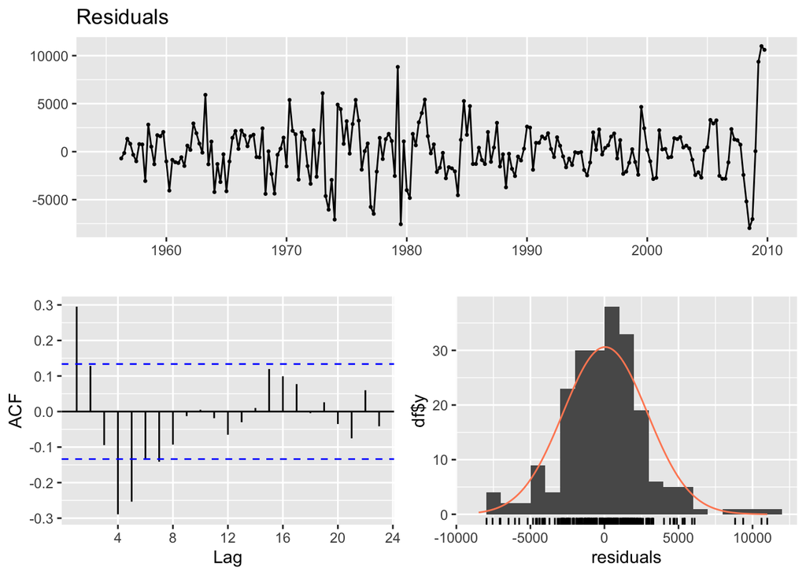

```
##
##  Ljung-Box test
##
## data:  Residuals
## Q* = 67.703, df = 8, p-value = 1.406e-11
##
## Model df: 0.   Total lags used: 8
```

```r
# Check residuals
residuals <- residuals(forecast_values)
checkresiduals(residuals)
```

```r
# Calculate squared differences between forecast and actual values
squared_diff <- (forecast_values$mean - test_data)^2

# Compute RMSE
rmse <- sqrt(mean(squared_diff))

# Print RMSE
print(paste("RMSE:", rmse))
```

```
## [1] "RMSE: 421396.929796303"
```

```r
#### NOTE THIS FORECAST IS DIFFERENCED DATA BUT THE TEST IS ACTUALS. WE NEED TO DE-DIFFERENCE THE FORECAST AND THEN COMPUTE ACCURACY
```